# Logistic Regression Assignment

Chris McLoy

## Logistic Regression

Logistic regression allows us to apply the power of regression to cases where our outcome variable is binary (0/1). The fitting process and coefficient interpretation are quite a bit different from linear regression. The technique is powerful and pretty ubiquitous in business, where there are many problems with binary outcomes (e.g., purchasing, re-purchasing, customer attrition, etc.)

## Instructions

Follow along in this document. There are places where I’ve added comments encouraging you to do analyses, make plots, etc. In the modeling section I’ve asked you to build a logistic regression model and in the interpretation section I’ve asked you to interpret it. Do so, then knit your model and commit both your knitted HTML and your RMD.

## Data

The data for this project comes from a local company, TOMIS, who manages bookings, websites, and marketing for a variety of tour operators. They’ve graciously allowed us to use a sample of data on customer booking habits. The data is pretty large (~52 MB) and can be downloaded from Moodle. Once you’ve downloaded it, extract it from its zip file into this folder.

The data set has the following columns:

1. `id`: a unique identifier for the customer.
2. `total_spent`: the amount of money the customer has spent with the tour operator.
3. `days_since_last`: the number of days since the last time the customer booked with this operator.
4. `bookings_in_last_13_months`: the number of bookings in the preceding 13 months.
5. `bookings_in_13_to_26_months`: the number of bookings 13 to 26 months ago.
6. `bookings_more_than_26_months`: the number of bookings more than 26 months ago.
7. `mean_dist_to_client_location`: the mean distance from the customer to the tour operator. This is missing for about 35% of rows.
8. `mean_leading_days`: the mean number of days that the customer books their experiences.
9. `mean_rebook_days`: if the customer rebooks, the mean number of days between those rebookings.
10. `booking_dt`: the calendar date and time of the booking.
11. `experience_dt`: the calendar date and time of the experience, which is what the tours or trips are called.
12. `client`: There are 14 clients in the data set. These are the tour operators.
13. `client_location`: Some clients have multiple locations. This field allows us to differentiate between them.
14. `guests`: The number of people on the experience.
15. `domain`: the web domain of the customer’s email.
16. `rebooked`: our response variable. Zero or one depending on whether or not the customer rebooks. There are 12.4% of rows that have rebookings.

## Data Exploration

Let’s take a look at rebooking rates by client:

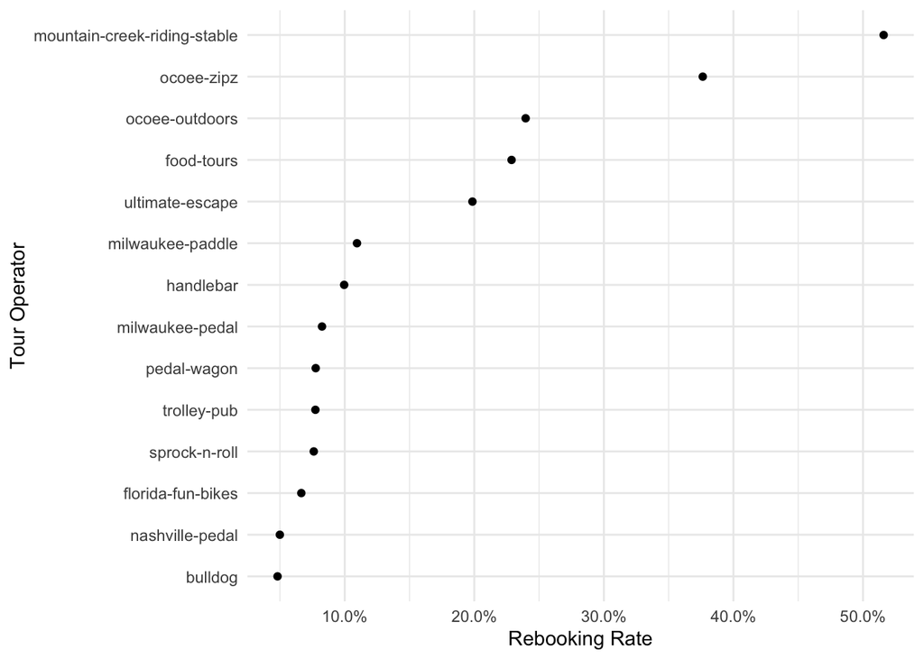

As we can see, there’s quite a bit of variability in rebooking rates across clients. Therefore, client is likely to be a useful explanatory variable in our model.

## Model

```
##
## Call:
## glm(formula = rebooked ~ client_fct + total_spent + bookings_in_13_to_26_months +
##     mean_leading_days, family = "binomial", data = d %>% slice_sample(prop = 0.5),
##     subset = total_spent < 20000)
##
## Deviance Residuals:
##     Min       1Q   Median       3Q      Max
## -2.7004  -0.4201  -0.3506  -0.3099   2.5607
##
## Coefficients:
##                                          Estimate Std. Error z value Pr(>|z|)
## (Intercept)                            -3.034e+00  3.333e-02 -91.027  < 2e-16
## client_fctnashville-pedal              -2.059e-01  4.649e-02  -4.429 9.45e-06
## client_fctflorida-fun-bikes            -1.332e-01  3.441e-01  -0.387 0.698691
## client_fctsprock-n-roll                 2.065e-01  1.218e-01   1.695 0.090162
## client_fcttrolley-pub                   3.577e-01  4.955e-02   7.219 5.23e-13
## client_fctpedal-wagon                   2.682e-01  5.186e-02   5.171 2.33e-07
## client_fctmilwaukee-pedal               2.123e-01  6.110e-02   3.474 0.000513
## client_fcthandlebar                     4.565e-01  5.123e-02   8.911  < 2e-16
## client_fctmilwaukee-paddle              5.005e-01  9.201e-02   5.440 5.34e-08
## client_fctultimate-escape               1.489e+00  4.289e-02  34.709  < 2e-16
## client_fctfood-tours                    1.506e+00  7.483e-02  20.129  < 2e-16
## client_fctocoee-outdoors                1.665e+00  7.356e-02  22.629  < 2e-16
## client_fctocoee-zipz                    2.337e+00  8.515e-02  27.444  < 2e-16
## client_fctmountain-creek-riding-stable  2.991e+00  4.140e-02  72.259  < 2e-16
## total_spent                             5.802e-04  3.323e-05  17.461  < 2e-16
## bookings_in_13_to_26_months             3.004e-01  3.289e-02   9.131  < 2e-16
## mean_leading_days                       3.908e-03  4.085e-04   9.567  < 2e-16
##
## (Intercept)                            ***
## client_fctnashville-pedal              ***
## client_fctflorida-fun-bikes
## client_fctsprock-n-roll                .
## client_fcttrolley-pub                  ***
## client_fctpedal-wagon                  ***
## client_fctmilwaukee-pedal              ***
## client_fcthandlebar                    ***
## client_fctmilwaukee-paddle             ***
## client_fctultimate-escape              ***
## client_fctfood-tours                   ***
## client_fctocoee-outdoors               ***
## client_fctocoee-zipz                   ***
## client_fctmountain-creek-riding-stable ***
## total_spent                            ***
## bookings_in_13_to_26_months            ***
## mean_leading_days                      ***
## ---
## Signif. codes:  0 '***' 0.001 '**' 0.01 '*' 0.05 '.' 0.1 ' ' 1
##
## (Dispersion parameter for binomial family taken to be 1)
##
##     Null deviance: 71605  on 101123  degrees of freedom
## Residual deviance: 60506  on 101107  degrees of freedom
## AIC: 60540
##
## Number of Fisher Scoring iterations: 5
```

The process I took was trial and error. At first I took the variables client_fct, total_spent, bookings > 26 months, and mean_leading days. Each one besides bookings >26 months had extremely low p values. Although the bookings > 26 months was still within the %5 acceptance range, I tried another model.

## Interpretation

```
## # A tibble: 14 x 5
##    client_fct          total_spent mean_leading_da… bookings_in_13_to_26…   prob
##    <fct>                     <dbl>            <dbl>                 <dbl>  <dbl>
##  1 handlebar                  222.             19.3                0.0234 0.0858
##  2 nashville-pedal            222.             19.3                0.0234 0.0461
##  3 trolley-pub                222.             19.3                0.0234 0.0783
##  4 milwaukee-paddle           222.             19.3                0.0234 0.0893
##  5 ultimate-escape            222.             19.3                0.0234 0.209
##  6 pedal-wagon                222.             19.3                0.0234 0.0721
##  7 mountain-creek-rid…        222.             19.3                0.0234 0.542
##  8 bulldog                    222.             19.3                0.0234 0.0561
##  9 milwaukee-pedal            222.             19.3                0.0234 0.0685
## 10 florida-fun-bikes          222.             19.3                0.0234 0.0495
## 11 sprock-n-roll              222.             19.3                0.0234 0.0681
## 12 food-tours                 222.             19.3                0.0234 0.211
## 13 ocoee-outdoors             222.             19.3                0.0234 0.239
## 14 ocoee-zipz                 222.             19.3                0.0234 0.381
```

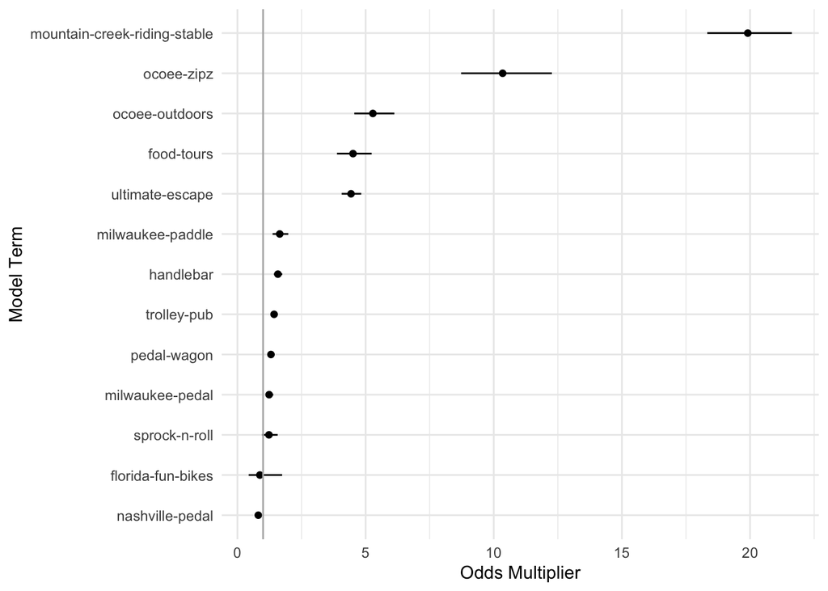

## Accuracy

|  | Pred No Rebook | Pred Rebook |
| --- | --- | --- |
| Didn’t Rebook | 17848 | 45 |
| Did Rebook | 2325 | 6 |